# Intro-to-ChIPseq

Mary Piper, Meeta Mistry, Radhika Khetani, Shicong Wang

6/11/2021

# Annotation and Functional Analysis

## Learning Objectives

- Annotating peaks with gene and genomic feature information
- Obtaining biological context for identified binding sites using functional enrichment tools
- Using the seqqunce data for peaks to identify possible over-represented motifs

We have identified regions of the genome that are enriched in the number of aligned reads for each of our transcription factors of interest, Nanog and Pou5f1. These enriched regions represent the likely locations of where these proteins bind to the genome. After we obtain a list of peak coordinates, **it is important to study the biological implications of the protein DNA bindings**. Certain questions have always been asked: what are the **genomic annotations and the functions** of these peak regions?

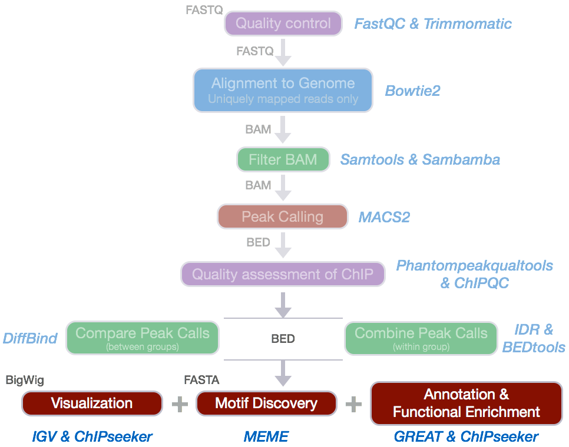

## Peak Annotation

Because many cis-regulatory elements are close to TSSs of their targets, it is common to associate each peak to its nearest gene, either upstream or downstream. [ChIPseeker](http://bioconductor.org/packages/release/bioc/vignettes/ChIPseeker/inst/doc/ChIPseeker.html) is an R Bioconductor package for annotating peaks. Additionally, it has various visualization functions to assess peak coverage over chromosomes and profiles of peaks binding to TSS regions.

### Setting up

1. Open up RStudio and open up the `chipseq-project` that we created previously.
2. Open up a new R script (‘File’ -> ‘New File’ -> ‘Rscript’), and save it as `chipseeker.R`

   > **NOTE:** This next section assumes you have the `ChIPseeker` package installed for R 3.5 or higher. You will also need one additional library for gene annotation. If you haven’t done this please run the following lines of code before proceeding.

```
  # BiocManager::install("ChIPseeker")
  # BiocManager::install("EnsDb.Hsapiens.v75")
  # BiocManager::install("clusterProfiler")
  # BiocManager::install("AnnotationDbi")
  # BiocManager::install("org.Hs.eg.db")
  # install("ChIPQC")
```

### Loading data

Peak annotation is generally performed on your high confidence peak calls (after looking at concordance betwee replicates). While we have a confident peak set for our data, this set is rather small and will not result in anything meaningful in our functional analyses. **We have generated a set of high confidence peak calls using the full dataset.** These were obtained post-IDR analysis, (i.e. concordant peaks between replicates) and are provided in BED format which is optimal input for the ChIPseeker package.

> **NOTE:** the number of peaks in these BED files are are significantly higher than what we observed with the smaller dataset that we have been working with.

We will need to copy over the appropriate files from O2 to our laptop. You can do this using `FileZilla` or the `scp` command.

Move over the **BED files from O2(`/n/groups/hbctraining/chip-seq/full-dataset/idr/*.bed`) to your laptop**. You will want to copy these files into your chipseq-project **into a new folder called `data/idr-bed`.**

To load the data into our R session, we need to provide the names of our BED files in a list format.

```r
# Load data
samplefiles <- list.files("./data/idr-bed", pattern= ".bed", full.names=T)
# samplefiles <- list.files("data/idr-bed", pattern= ".bed", full.names=T)
samplefiles <- as.list(samplefiles)
names(samplefiles) <- c("Nanog", "Pou5f1")
```

Next, we need to **assign annotation databases** generated from UCSC to a variable:

```r
    txdb <- TxDb.Hsapiens.UCSC.hg19.knownGene
```

> **NOTE:** *ChIPseeker supports annotating ChIP-seq data of a wide variety of species if they have transcript annotation TxDb object available.* To find out which genomes have the annotation available follow [this link](http://bioconductor.org/packages/3.5/data/annotation/) and scroll down to “TxDb”. Also, if you are interested in creating your own TxDb object you will find [more information here](https://bioconductor.org/packages/devel/bioc/vignettes/GenomicFeatures/inst/doc/GenomicFeatures.pdf).

### Annotation

Many annotation tools use nearest gene methods for assigning a peak to a gene in which the algorithm looks for the nearest TSS to the given genomic coordinates and annotates the peak with that gene. This can be misleading as **binding sites might be located between two start sites of different genes**.

The **`annotatePeak` function**, as part of the ChIPseeker package, uses the nearest gene method described above but also **provides parameters to specify a max distance from the TSS.** For annotating genomic regions, `annotatePeak` will not only give the gene information but also reports detail information when genomic region is Exon or Intron. For instance, âExon (uc002sbe.3/9736, exon 69 of 80)â, means that the peak overlaps with the 69th exon of the 80 exons that transcript uc002sbe.3 possess and the corresponding Entrez gene ID is 9736.

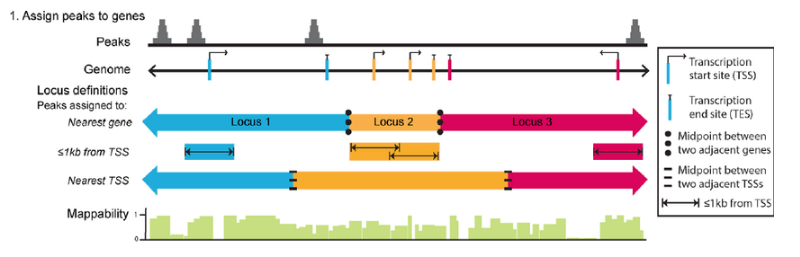

Let’s start by retrieving annotations for our Nanog and Pou5f1 peaks calls:

```r
peakAnnoList <- lapply(samplefiles, annotatePeak, TxDb=txdb,
                       tssRegion=c(-1000, 1000), verbose=FALSE)
```

If you take a look at what is stored in `peakAnnoList`, you will see that the peak annotations have been summarized for you based on genomic features:

[output not shown]

ChIPseeker provides several functions to visualize the annotations using various plots. We will demonstrate a few of these using the Nanog sample. We will also show you how some of the functions can support comparing annotation information across samples.

> **NOTE**: ChIPseeker also has functionality to **generate figures for visualization** (similar to what we did in `deepTools`). If you are interested in testing out those functions on this data, please see the [materials linked here](https://hbctraining.github.io/Intro-to-ChIPseq/lessons/chipseeker_visualization.html).

### Barchart of genomic feature representation

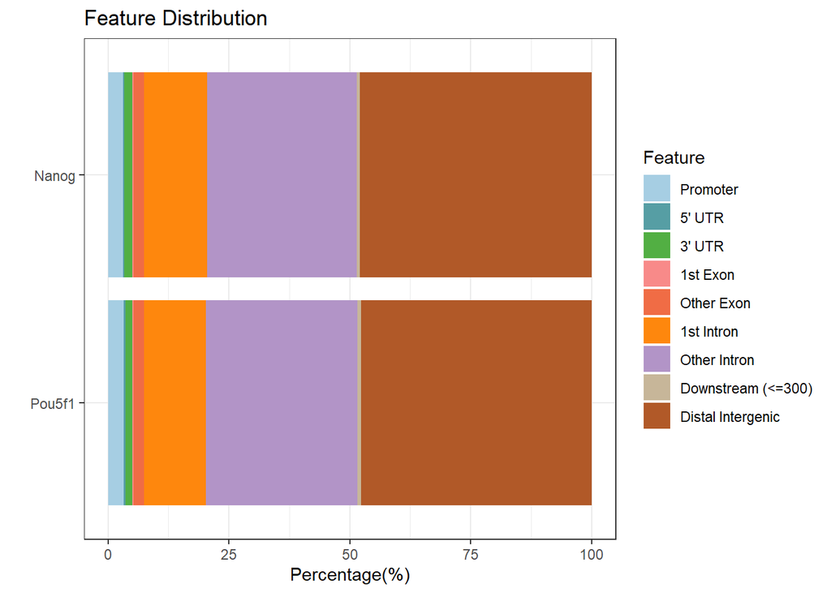

```r
plotAnnoBar(peakAnnoList)
```

### Distribution of TF-binding loci relative to TSS

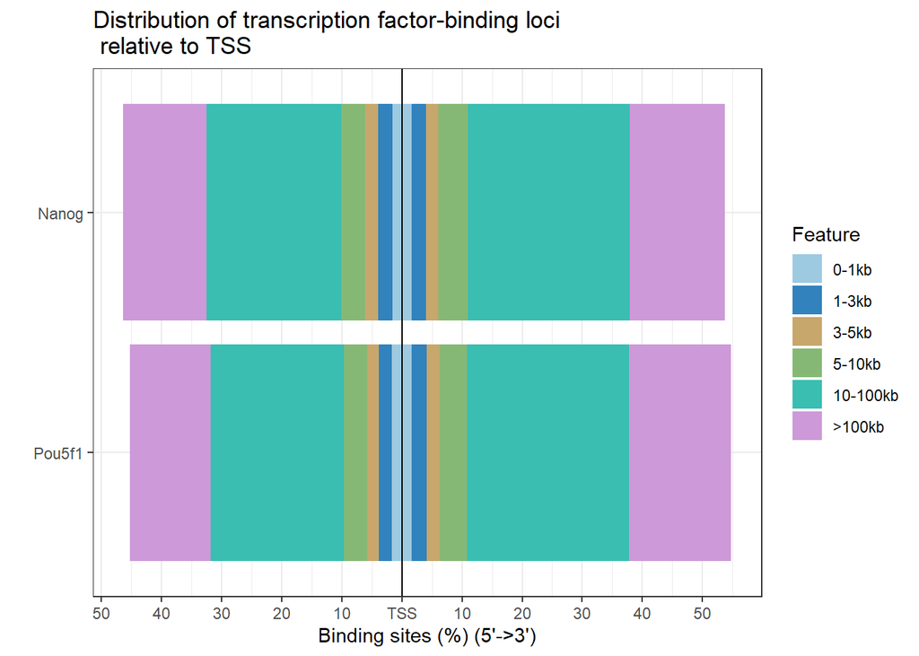

```r
plotDistToTSS(peakAnnoList, title="Distribution of transcription factor-binding loci \n relative to TSS")
```

Finally, it would be nice to have the **annotations for each peak call written to file**, as it can be useful to browse the data and subset calls of interest. The annotation information is stored in the `peakAnnoList` object. To retrieve it we use the following syntax:

```r
    nanog_annot <- data.frame(peakAnnoList[["Nanog"]]@anno)
```

Take a look at this data frame. You should see columns corresponding to your input BED file and addditional columns containing nearest gene(s), the distance from peak to the TSS of its nearest gene, genomic feature annotation of the peak and other information. Since some annotations may overlap, ChIPseeker has adopted the following priority in how it lists information:

- Promoter
- 5’ UTR
- 3’ UTR
- Exon
- Intron
- Downstream (defined as the downstream of gene end)
- Intergenic

One thing you will notice is that the gene identifiers that are listed are EntrezIDs. It would be easier to browse through the results if we had gene symbols. We will obtain this information using `AnnotationDbi`, an R package that provides an interface for connecting and querying various annotation databases using SQLite data storage. The AnnotationDbi packages can query the OrgDb, TxDb, EnsDb, Go.db, and BioMart annotations. There is [helpful documentation](https://bioconductor.org/packages/release/bioc/vignettes/AnnotationDbi/inst/doc/IntroToAnnotationPackages.pdf) available to reference when extracting data from any of these databases.

Although we have been using the TxDb database with ChIPseeker, there is limited options as to what other identifiers can be retrieved.

```
keytypes(TxDb.Hsapiens.UCSC.hg19.knownGene)
[1] "CDSID"    "CDSNAME"  "EXONID"   "EXONNAME" "GENEID"   "TXID"     "TXNAME"
```

Since we want to map our EntrezIDs to gene symbols, we will need to use another database. The `EnsDb.Hsapiens.v75` database corresponds to hg19, and so is an appropriate option.

```r
# Get the entrez IDs
entrez <- nanog_annot$geneId

# Return the gene symbol for the set of Entrez IDs
annotations_edb <- AnnotationDbi::select(EnsDb.Hsapiens.v75,
                                         keys = entrez,
                                         columns = c("GENENAME"),
                                         keytype = "ENTREZID")

# Change IDs to character type to merge
annotations_edb$ENTREZID <- as.character(annotations_edb$ENTREZID)

# Write to file
# nanog_annot %>%
#   left_join(annotations_edb, by=c("geneId"="ENTREZID")) %>%
#   write.table(file="results/Nanog_peak_annotation.txt", sep="\t", quote=F, row.names=F)
```

## Functional enrichment: R-based tools

Once we have obtained gene annotations for our peak calls, we can perform functional enrichment analysis to **identify predominant biological themes among these genes** by incorporating knowledge from biological ontologies such as Gene Ontology, KEGG and Reactome. The gene lists we have obtained through annotation can be interepreted using freely available web- and R-based tools. In this workshop we will focus on the latter, but we will also mention the former and provide resources if you are interested in web-based tools.

### Over-representation analysis

There are a plethora of functional enrichment tools that perform some type of over-representation analysis by querying databases containing information about gene function and interactions. Querying these databases for gene function requires the use of a consistent vocabulary to describe gene function. One of the **most widely-used vocabularies is the Gene Ontology (GO)**. This vocabulary was established by the Gene Ontology project, and the words in the vocabulary are referred to as GO terms.

We will be using [`clusterProfiler`](http://bioconductor.org/packages/release/bioc/html/clusterProfiler.html) to perform over-representation analysis on GO terms associated with our list of significant genes. The tool takes as input a significant gene list and a background gene list and performs statistical enrichment analysis using hypergeometric testing. The basic arguments allow the user to select the appropriate organism and GO ontology (BP, CC, MF) to test.

Let’s start with our gene list from **Nanog annotations** and use them as input for a **GO enrichment analysis of biological process terms**.

```r
# Run GO enrichment analysis
ego <- enrichGO(gene = entrez,
                    keyType = "ENTREZID",
                    OrgDb = org.Hs.eg.db,
                    ont = "BP",
                    pAdjustMethod = "BH",
                    qvalueCutoff = 0.05,
                    readable = TRUE)
```

The `ego` object we created contains the results of the over-representation analysis. We can extract it into a data frame and **write the results to file**:

```r
# Output results from GO analysis to a table
cluster_summary <- data.frame(ego)
write.csv(cluster_summary, "results/clusterProfiler_Nanog.csv")
```

We can also use the `ego` object to **visualize the results** using the `dotplot()` function. The **dotplot** shows the number of genes associated with the first 50 terms (size) and the p-adjusted values for these terms (color). This plot displays the top 50 genes by gene ratio (# genes related to GO term / total number of sig genes), not p-adjusted value.

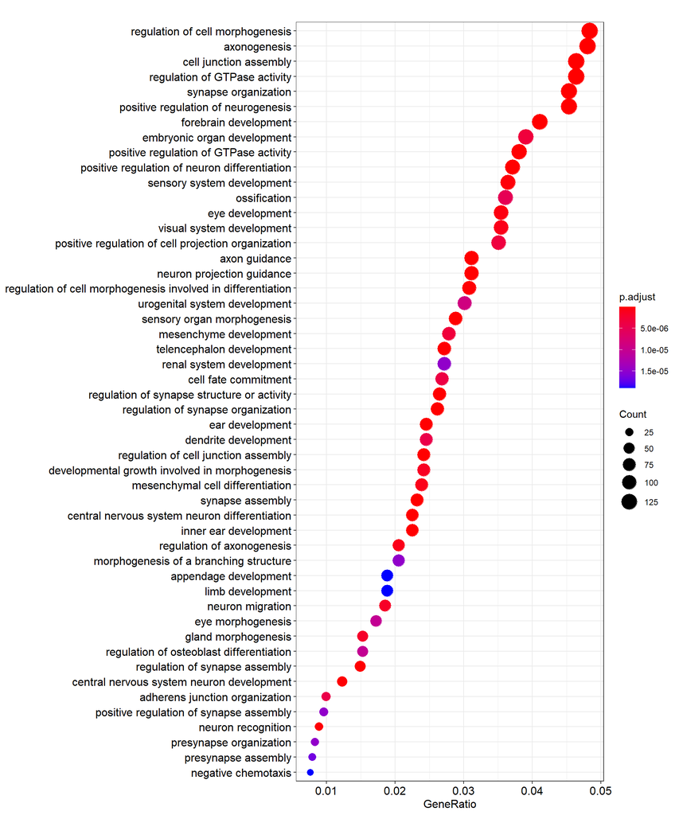

```r
# Dotplot visualization
dotplot(ego, showCategory=50)
```

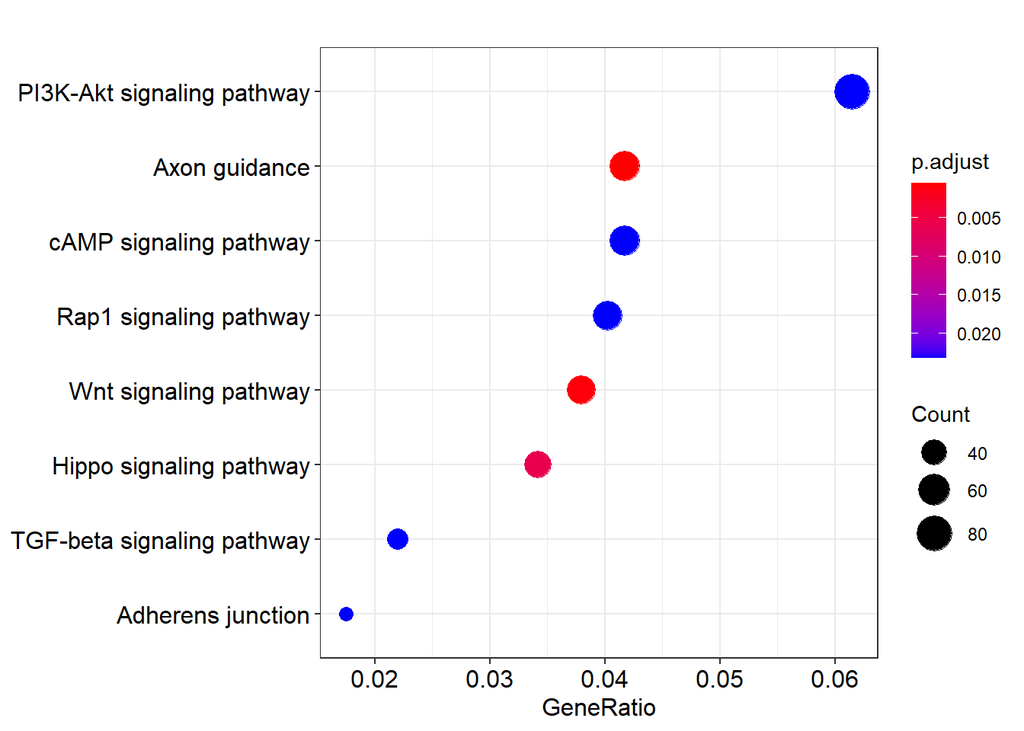

```r
ekegg <- enrichKEGG(gene = entrez,
                 organism = 'hsa',
                 pvalueCutoff = 0.05)

dotplot(ekegg)
```

### Comparing enrichment across samples

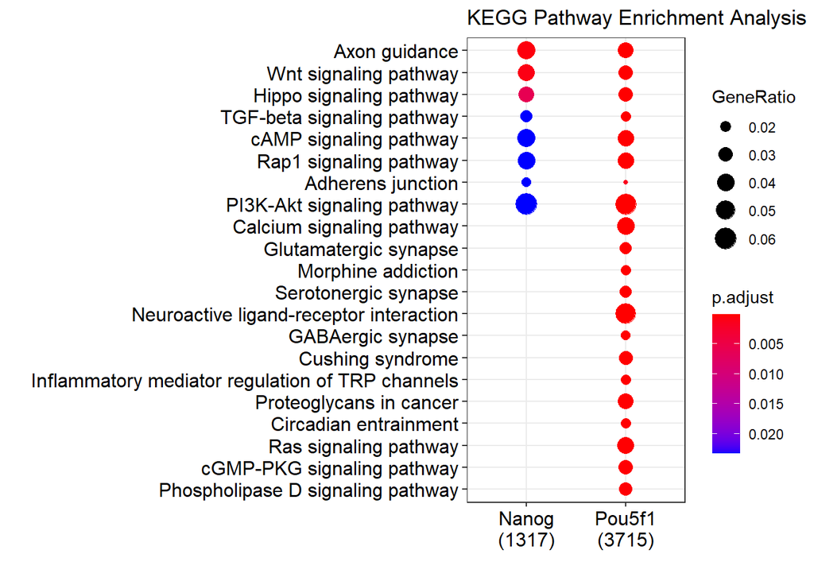

```r
# Create a list with genes from each sample
genes = lapply(peakAnnoList, function(i) as.data.frame(i)$geneId)

# Run KEGG analysis
compKEGG <- compareCluster(geneCluster = genes,
                         fun = "enrichKEGG",
                         organism = "human",
                         pvalueCutoff  = 0.05,
                         pAdjustMethod = "BH")
dotplot(compKEGG, showCategory = 20, title = "KEGG Pathway Enrichment Analysis")
```

## Functional enrichment: Web-based tools

There are also web-based tool for enrichment analysis on genomic regions, and **a popular one is [GREAT](http://great.stanford.edu/public/html/)** (Genomic Regions Enrichment of Annotations Tool). GREAT is used to analyze the functional significance of cis-regulatory regions identified by localized measurements of DNA binding events across an entire genome[1](http://bejerano.stanford.edu/papers/GREAT.pdf). It **incorporates annotations from 20 different ontologies** and is an easy to use tool which generates annotation and downstream functional enrichement results for genomic coordinate files. The utility of GREAT is not limited to ChIP-seq, as it could also be applied to open chromatin, localized epigenomic markers and similar functional data sets, as well as comparative genomics sets.

In the interest of time we will not go into the details of using GREAT, however we have [materials linked here](https://hbctraining.github.io/Intro-to-ChIPseq/lessons/web_based_functional_analysis.html) if you are interested in testing it out with this dataset. There also [demo datasets](http://great.stanford.edu/public/html/demo.php) on the GREAT website that you can use to test out the functionality of the tool.

## Motif discovery

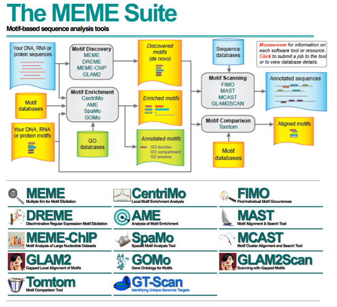

MEME_suite

To identify over-represented motifs, we will use DREME from the MEME suite of sequence analysis tools. [DREME](http://meme-suite.org/tools/dreme) is a motif discovery algorithm designed to find short, core DNA-binding motifs of eukaryotic transcription factors and is optimized to handle large ChIP-seq data sets.

DREME is tailored to eukaryotic data by focusing on short motifs (4 to 8 nucleotides) encompassing the DNA-binding region of most eukaryotic monomeric transcription factors. Therefore it may miss wider motifs due to binding by large transcription factor complexes.

### DREME

Visit the [DREME website](http://meme-suite.org/tools/dreme) and perform the following steps:

1. You will **need a FASTA file which contains the sequences of all of the genomic regions of interest**. This can be generated from your IDR BED files by following the instructions in our [materials linked here](https://hbctraining.github.io/Intro-to-ChIPseq/lessons/motif_analysis_prep.html). In the interest of time, we have generated this file for you (using the full dataset) and it can be [downloaded via this link](https://github.com/hbctraining/Intro-to-ChIPseq/raw/master/Nanog-idr-merged-dreme.fasta).
2. Select the downloaded `Nanog-idr-merged-dreme.fasta` as input to DREME
3. Enter your email address so that DREME can email you once the analysis is complete
4. Enter a job description so you will recognize which job has been emailed to you and then start the search

You will be shown a status page describing the inputs and the selected parameters, as well as links to the results at the top of the screen.

[figure not shown]

results_page

This may take some time depending on the server load and the size of the file. While you wait, take a look at the [expected results](https://github.com/hbctraining/Intro-to-ChIPseq/raw/master/chipseq_DREME_report.pdf).

[figure not shown]

dreme_output

DREMEâs HTML output provides a list of Discovered Motifs displayed as sequence logos (in the forward and reverse complement (RC) orientations), along with an E-value for the significance of the result.

Motifs are significantly enriched if the fraction of sequences in the input dataset matching the motif is significantly different from the fraction of sequences in the background dataset using Fisherâs Exact Test. Typically, background dataset is either similar data from a different ChIP-seq experiment or shuffled versions of the input dataset [[1](http://www.ncbi.nlm.nih.gov/pmc/articles/PMC3106199/)].

Clicking on `More` displays the number of times the motif was identified in the Nanog dataset (positives) versus the background dataset (negatives). The `Details` section displays the number of sequences matching the motif, while `Enriched Matching Words` displays the number of times the motif was identified in the sequences (more than one word possible per sequence).

### Tomtom

To determine if the identified motifs resemble the binding motifs of known transcription factors, we can submit the motifs to Tomtom, which searches a database of known motifs to find potential matches and provides a statistical measure of motif-motif similarity. We can run the analysis individually for each motif prediction by performing the following steps:

1. Click on the `Submit / Download` button for motif `ATGYWAAT` in the DREME output
2. A dialog box will appear asking you to Select what you want to do or Select a program. Select `Tomtom` and click `Submit`. This takes you to the input page.
3. Tomtom allows you to select the database you wish to search against. Keep the default parameters selected, but keep in mind that there are other options when performing your own analyses.
4. Enter your email address and job description and start the search.

You will be shown a status page describing the inputs and the selected parameters, as well as a link to the results at the top of the screen. Clicking the link displays an output page that is continually updated until the analysis has completed. Like DREME, Tomtom will also email you the results.

The HTML output for Tomtom shows a list of possible motif matches for the DREME motif prediction generated from your Nanog regions. Clicking on the match name shows you an alignment of the predicted motif versus the match. [Click here to visualize a PDF of the report](https://github.com/hbctraining/Intro-to-ChIPseq/raw/master/chipseq_TOMTOM_report.pdf)

[figure not shown]

tomtom_output

The short genomic regions identified by ChIP-seq are generally very highly enriched with binding sites of the ChIP-ed transcription factor, but Nanog is not in the databases of known motifs. The regions identified also tend to be enriched for the binding sites of other transcription factors that bind *cooperatively or competitively* with the ChIP-ed transcription factor.

If we compare our results with what is known about our transcription factor, Nanog, we find that Sox2 and Pou5f1 (Oct4) co-regulate many of the same genes as Nanog.

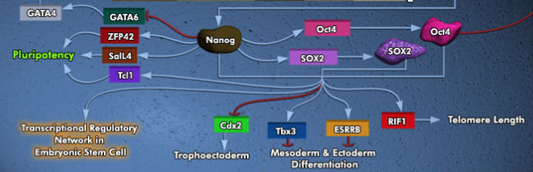

https://www.qiagen.com/us/shop/genes-and-pathways/pathway-details/?pwid=309

### MEME-ChIP

MEME-ChIP is a tool that is part of the MEME Suite that is specifically designed for ChIP-seq analyses. MEME-ChIP performs DREME and Tomtom analysis in addition to using tools to assess which motifs are most centrally enriched (motifs should be centered in the peaks) and to combine related motifs into similarity clusters. It is able to identify longer motifs < 30bp, but takes much longer to run. The report generated by MEME-ChIP is available [here](https://github.com/hbctraining/Intro-to-ChIPseq/raw/master/chipseq_MEME%20ChIP_report.pdf).

[figure not shown]

# Integrated ChIP-seq Data Analysis Workshop

## Example1: annotate ChIP-seq peaks with ChIPpeakAnno

Four steps:

1. Read in peak data with `toGRanges`
2. Generate annotation data with `toGRanges`
3. Annotate peaks with `annotatePeakInBatch`
4. Add additional info with `addGeneIDs`

### Step1: read in peak data

We first need to convert peak files from bed/broadPeak/narrowPeak etc. format to `GRanges` object with `toGRanges` function.

For the demo, we will use the example data stored in ChIPpeakAnno package.

```r
## locate example data:
path <- system.file("extdata", "Tead4.broadPeak", package="ChIPpeakAnno")
## read in peak file:
peaks <- toGRanges(path, format="broadPeak")
## inspect the top 2 lines of the peak file in GRanges format:
head(peaks, n=2)
```

```
## GRanges object with 2 ranges and 4 metadata columns:
##             seqnames        ranges strand |     score signalValue    pValue
##                <Rle>     <IRanges>  <Rle> | <integer>   <numeric> <numeric>
##   peak12338     chr2 175473-176697      * |       206      668.42        -1
##   peak12339     chr2 246412-246950      * |        31      100.23        -1
##                qValue
##             <numeric>
##   peak12338        -1
##   peak12339        -1
##   -------
##   seqinfo: 1 sequence from an unspecified genome; no seqlengths
```

### Step2: prepare annotation data

Depending on your research goals, you can choose to use either ENSEMBL or UCSC annotations.

The more complex ENSEMBL annotation is preferred when the goal is to discover and explain unknown biological mechanisms.

The less complex UCSC annotation can be used to generate more robust and reproducible results.

```r
library(TxDb.Hsapiens.UCSC.hg19.knownGene)
annoDataTxDb <- toGRanges(TxDb.Hsapiens.UCSC.hg19.knownGene)
## inspect the first two lines of the annotation file:
head(annoDataTxDb, n=2)
```

```
## GRanges object with 2 ranges and 0 metadata columns:
##      seqnames            ranges strand
##         <Rle>         <IRanges>  <Rle>
##    1    chr19 58858172-58874214      -
##   10     chr8 18248755-18258723      +
##   -------
##   seqinfo: 93 sequences (1 circular) from hg19 genome
```

### Step3: annotate peaks

```r
## annotate by the nearest TSS based on UCSC hg19 annotations
annoTxDb <- annotatePeakInBatch(peaks, AnnotationData=annoDataTxDb)
## inspect the first two lines of the annotation:
head(annoTxDb, n=2)
```

```
## GRanges object with 2 ranges and 13 metadata columns:
##                   seqnames        ranges strand |     score signalValue
##                      <Rle>     <IRanges>  <Rle> | <integer>   <numeric>
##   peak12338.26751     chr2 175473-176697      * |       206      668.42
##   peak12339.26751     chr2 246412-246950      * |        31      100.23
##                      pValue    qValue        peak     feature start_position
##                   <numeric> <numeric> <character> <character>      <integer>
##   peak12338.26751        -1        -1   peak12338       26751         218136
##   peak12339.26751        -1        -1   peak12339       26751         218136
##                   end_position feature_strand insideFeature distancetoFeature
##                      <integer>    <character>   <character>         <numeric>
##   peak12338.26751       264810              -    downstream             89337
##   peak12339.26751       264810              -        inside             18398
##                   shortestDistance fromOverlappingOrNearest
##                          <integer>              <character>
##   peak12338.26751            41439          NearestLocation
##   peak12339.26751            17860          NearestLocation
##   -------
##   seqinfo: 1 sequence from an unspecified genome; no seqlengths
```

### Step4: add additional annotation

```r
library(org.Hs.eg.db)
## add in gene symbol
annoTxDb <- addGeneIDs(annoTxDb, orgAnn="org.Hs.eg.db",
                        feature_id_type="entrez_id",
                        IDs2Add=c("symbol"))
## inspect the first two lines:
head(annoTxDb, n=2)
```

```
## GRanges object with 2 ranges and 14 metadata columns:
##                   seqnames        ranges strand |     score signalValue
##                      <Rle>     <IRanges>  <Rle> | <integer>   <numeric>
##   peak12338.26751     chr2 175473-176697      * |       206      668.42
##   peak12339.26751     chr2 246412-246950      * |        31      100.23
##                      pValue    qValue        peak     feature start_position
##                   <numeric> <numeric> <character> <character>      <integer>
##   peak12338.26751        -1        -1   peak12338       26751         218136
##   peak12339.26751        -1        -1   peak12339       26751         218136
##                   end_position feature_strand insideFeature distancetoFeature
##                      <integer>    <character>   <character>         <numeric>
##   peak12338.26751       264810              -    downstream             89337
##   peak12339.26751       264810              -        inside             18398
##                   shortestDistance fromOverlappingOrNearest      symbol
##                          <integer>              <character> <character>
##   peak12338.26751            41439          NearestLocation      SH3YL1
##   peak12339.26751            17860          NearestLocation      SH3YL1
##   -------
##   seqinfo: 1 sequence from an unspecified genome; no seqlengths
```

Short summary:

Be careful that peak annotation results may differ depending on the source of your annotation file.

## Example2: find overlaps for replicates

The output **overlappingPeaks** object of the module `findOverlapsOfPeaks` consists of the followings:

1. venn_cnt
2. peaklist: a list of overlapping or unique peaks
3. overlappingPeaks: a list of data frame that consists of the annotations of all overlapping peaks

Below, we would like to find the overlaps between two peak files: one from BED, the other from GFF.

```r
library(ChIPpeakAnno)
## convert BED file to GRanges:
bed <- system.file("extdata", "MACS_output.bed", package="ChIPpeakAnno")
gr1 <- toGRanges(bed, format="BED", header=FALSE)
## convert GFF file to GRanges:
gff <- system.file("extdata", "GFF_peaks.gff", package="ChIPpeakAnno")
gr2 <- toGRanges(gff, format="GFF", header=FALSE, skip=3)
## must keep the class of gr2$score the same as gr1$score, i.e., numeric:
gr2$score <- as.numeric(gr2$score)
## find overlaps:
ol <- findOverlapsOfPeaks(gr1, gr2, connectedPeaks = "keepAll")
## add metadata (mean of score) to the overlapping peaks
ol <- addMetadata(ol, colNames="score", FUN=mean)
## inspect the first two lines of overlapping peaks:
head(ol$peaklist[["gr1///gr2"]], n=2)
```

```
## GRanges object with 2 ranges and 2 metadata columns:
##       seqnames        ranges strand |                           peakNames
##          <Rle>     <IRanges>  <Rle> |                     <CharacterList>
##   [1]     chr1 713791-715578      * | gr1__MACS_peak_13,gr2__001,gr2__002
##   [2]     chr1 724851-727191      * |          gr2__003,gr1__MACS_peak_14
##           score
##       <numeric>
##   [1]   850.203
##   [2]    29.170
##   -------
##   seqinfo: 1 sequence from an unspecified genome; no seqlengths
```

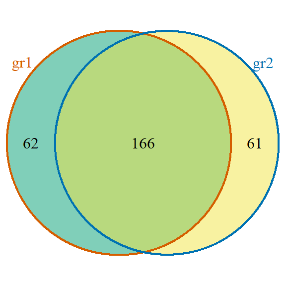

Venn diagram of overlaps for replicates

```
## $p.value
##      gr1 gr2 pval
## [1,]   1   1    0
##
## $vennCounts
##      gr1 gr2 Counts count.gr1 count.gr2
## [1,]   0   0      0         0         0
## [2,]   0   1     61         0        61
## [3,]   1   0     62        62         0
## [4,]   1   1    166       168       169
## attr(,"class")
## [1] "VennCounts"
```

```r
## make a Venn diagram:
makeVennDiagram(ol, fill=c("#009E73", "#F0E442"),
                     col=c("#D55E00", "#0072B2"),
                 cat.col=c("#D55E00", "#0072B2"))
```

## Example3: visualize peak site distribution

The `assignChromosomeRegion` function summarizes the distribution of peaks over various features (exon, intron, enhancer, promoter and UTR).

Results can be displayed in either peak-centric or nucleotide-centric view.

Note that a single peak might span multiple type of features.

#### Binding site relative to features

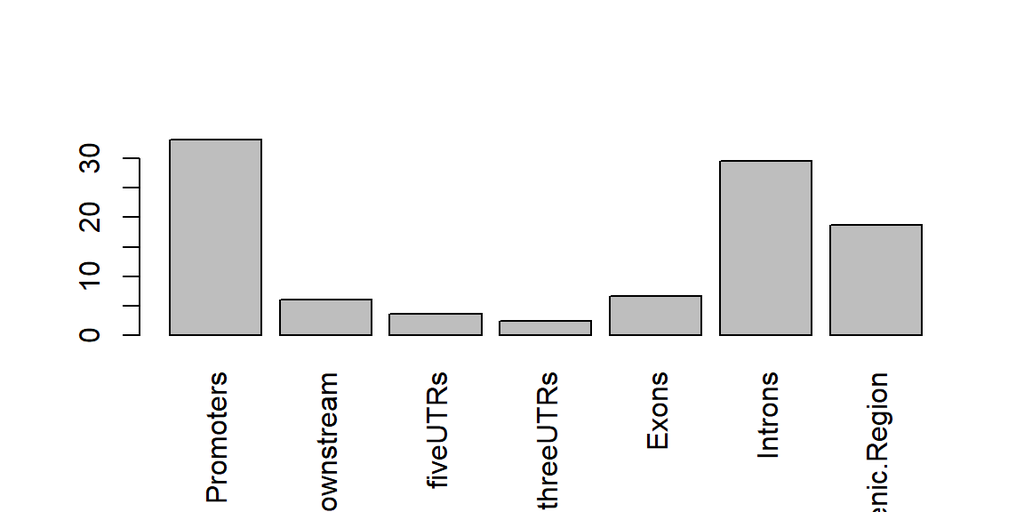

Peak distribution over different genomic features.

```r
library(TxDb.Hsapiens.UCSC.hg19.knownGene)
## get overlapping peaks:
overlaps <- ol$peaklist[["gr1///gr2"]]
## find peak site distribution:
aCR <- assignChromosomeRegion(overlaps, nucleotideLevel=FALSE,
                              precedence=c("Promoters",
                                           "immediateDownstream",
                                           "fiveUTRs",
                                           "threeUTRs",
                                           "Exons",
                                           "Introns"),
                              TxDb=TxDb.Hsapiens.UCSC.hg19.knownGene)
## use barplot to visualize:
barplot(aCR$percentage, las=3)
```